# 2 Introduction à R et opérations de base

Auteur

Affiliation

Daniel Coulombe

Institut des Sciences, Technologies et Études Avancées d’Haïti (ISTEAH)

Date

28/03/2024

## 2.1 Introduction

Pour les besoins des discussions à venir, et surtout de la méthodologie utilisée, les logiciels R et RStudio seront nécessaires. Sans que l’on cherche à devenir spécialistes de la programmation R, nous devons connaître les éléments fondamentaux du langage. Tout au long de ce document, des codes R sont introduits pour illustrer diverses opérations. Prenez le temps nécessaire pour examiner comment les diverses fonctions et opérateurs sont utilisés pour la solution des problèmes présentés, et exécutez les codes R proposés pour en vérifier les résultats. Les opérations à effectuer sont relativement simples, et très souvent il suffit de copier un texte et de le coller dans une fenêtre spécifique.

La documentation pertinente est très volumineuse, tant sous forme de manuel que de sites WEB accessibles via Internet. Le présent chapitre repose d’ailleurs sur nombre d’entre eux.

## 2.2 Installation des logiciels R et RStudio:

L’installation des logiciels requis est simple et n’est pas différente de l’installation de tout autre logiciel. Effectuez les deux étapes suivantes dans l’ordre:

- Rendez-vous sur le site de téléchargement de [**R**](http://www.r-project.org/) et installez la version de R correspondant à votre système d’exploitation.
- Rendez-vous sur le site de téléchargement de [**RStudio**](https://www.rstudio.com/products/rstudio/download/#download) et cliquez sur le lien indiqué sous **Download**, et finalement sur le bouton libellé **DOWNLOAD RSTUDIO FOR WINDOWS**. Si vous utilisez un système d’exploitation différent, sélectionnez la version pertinente dans la liste apparaissant sous **ALL INSTALLERS** . Suivez les instructions pour installer RStudio.

```r
x <- 25
x == 10
```

Sélectionnez ensuite que vous venez d’écrire en cliquant et en faisant glisser le curseur pour surligner les deux lignes de code. Finalement, cliquez sur le bouton libellé “**Exécuter**”. Si tout fonctionne correctement, la console doit afficher **FALSE**. La valeur de **x** a été fixée à 25, et ensuite on a posé la question: **est-ce que x est égal à 10?**, ce qui est **FAUX**.

## 2.3 L’environnement de travail

Par défaut, le langage utilisé par les logiciels R et RStudio est l’anglais. Pour utiliser le français au niveau des menus et des messages apparaissant à l’écran, il suffira d’inscrire dans la console R, ou celle de RStudio, la commande:

```r
Sys.setenv(LANG = "fr")
```

On peut également obtenir un environnement espagnol en remplaçant **“fr”** par **“es”**, dans cette commande.

Les logiciels requis (**R** et **RStudio**) sont maintenant prêts à l’action. Dans cette section, nous explorerons votre environnement de travail en détail. Une bonne connaissance de cet environnement vous donnera une grande efficacité dans les opérations à venir.

### 2.3.1 La console R

Lorsque vous lancez **R**, une fenêtre s’ouvre, quelques paragraphes apparaissent, suivis par une invite de commande: **>**. Vous êtes à la **CONSOLE**. L’interaction de base avec R se fait en inscrivant des commandes à ce niveau. La Figure 2.1 affiche la console apparaissant au lancement de R.

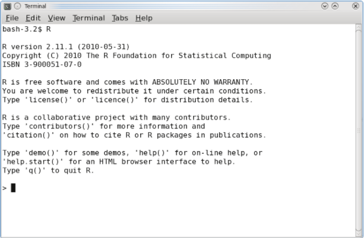

Figure 2.1: R - la Console

#### 2.3.1.1 Utilisation de la Console

- Tout en bas de la CONSOLE, vous trouverez le symbole “>”. Il indique l’endroit où vous pouvez inscrire vos commandes. Lorsqu’une commande est inscrite, il suffit d’appuyer sur ‘ENTRÉE’ pour que le résultat s’affiche à la ligne suivante, à moins que la commande soit une définition de variable. Si la commande est erronée, un message d’erreur sera affiché. Par exemple:

```r
6+7*5/2-2
```

```
#> [1] 21.5
```

On retrouve dans cette expression les 4 opérateurs arithmétiques de base: +, -, * et /. La multiplication (*) et la division (/) ont précédence et sont exécutées en premier lieu. Par la suite, l’addition (+) et la soustraction sont appliquées. Le résultat de l’expression ci-dessus est donc obtenu par:

7*5/2 = 35/2 = **17.5**

6+17.5-2 = **21.5**

On peut également utiliser les parenthèses pour altérer la séquence des opérations. Reprenant l’exemple précédent:

```r
(6+7)*5/2-2
```

```
#> [1] 30.5
```

Ici, le contenu de la parenthèse est exécuté avant toute autre opération, suivi des opérations impliquant multiplication et division, et finalement on termine par les opérations impliquant addition et soustraction:

13*5/2 = **32.5**

32.5-2 = **30.5**

On peut donc utiliser la console comme on le ferait d’un simple calculateur! Mais vous comprendrez que R offre beaucoup plus de possibilités!…

Transcrivez, ou Copiez/Collez les lignes suivantes dans la console:

```r
x <- 1:10
y <- round(runif(10), 2)
df <- data.frame(x, y)
df
```

Ce que vous venez de faire, c’est de créer une variable **x** contenant les entiers de 1 à 10; puis vous avez généré 10 nombres au hasard compris entre 0 et 1, et les avez arrondis à 2 décimales près, formant une nouvelle variable **y**. Finalement, vous avez uni les deux variables dans un contenant, **df**, pour ensuite afficher le résultat! Vous devriez avoir obtenu:

```
#>     x    y
#> 1   1 0.73
#> 2   2 0.50
#> 3   3 0.04
#> 4   4 0.53
#> 5   5 0.49
#> 6   6 0.30
#> 7   7 0.48
#> 8   8 0.46
#> 9   9 0.37
#> 10 10 0.30
```

Sous R, il est très facile d’obtenir des graphiques. Essayez les commandes suivantes, et voyez le résultat:

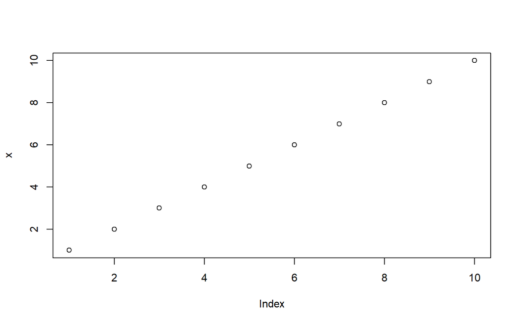

Valeur de X en séquence

```r
plot(x)
```

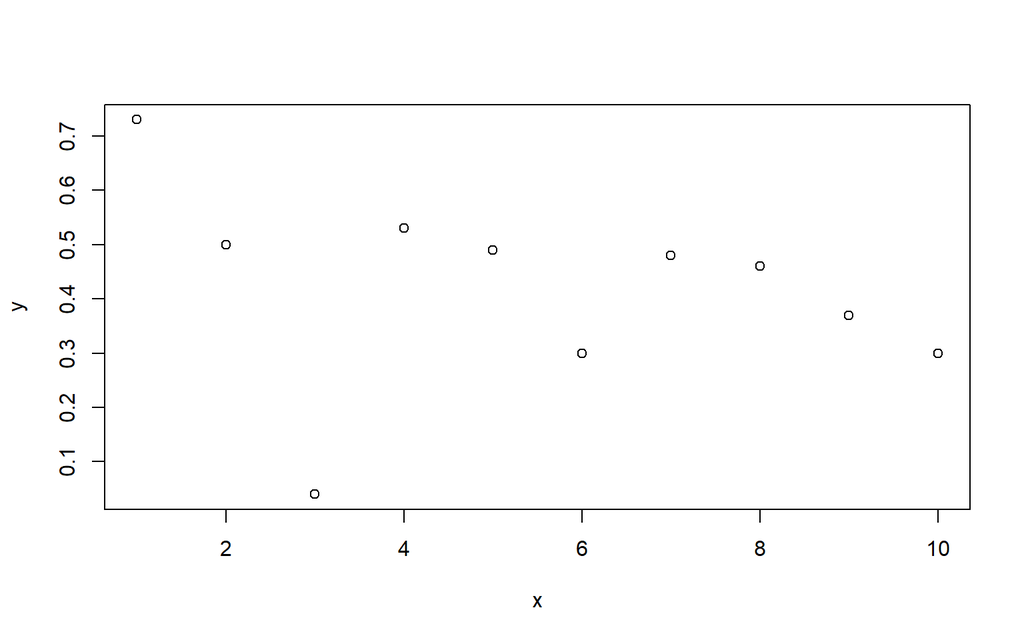

Relation entre X et Y

```r
plot(x,y)
```

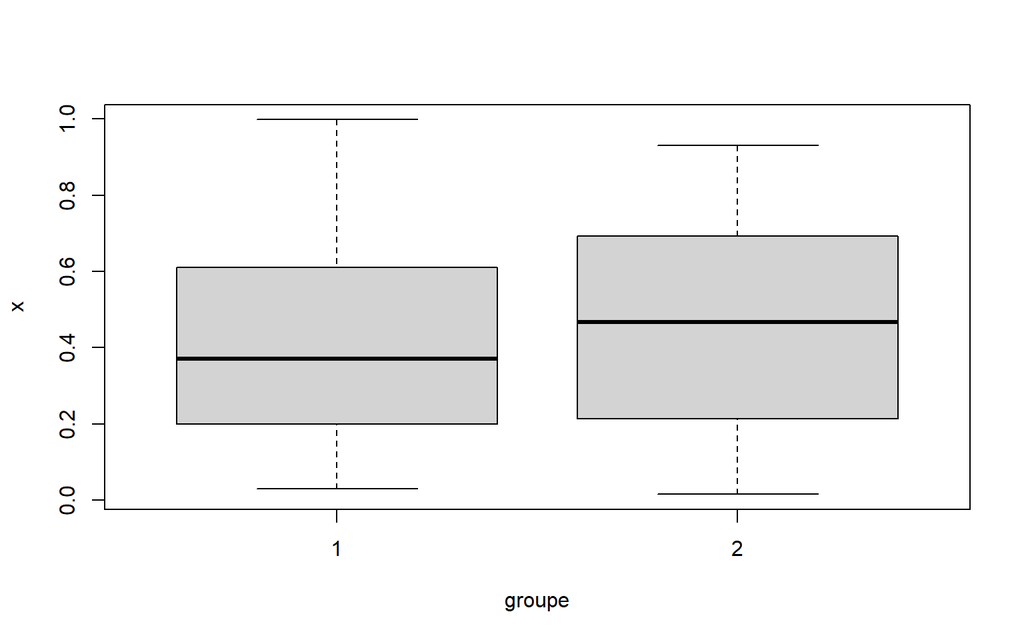

Diagramme en boîte

```r
x <- runif(100)
groupe <- rep(1:2,50)
boxplot(x~groupe)
```

Essentiellement, l’environnement R permet d’effectuer autant les calculs simples comme le ferait une calculatrice, que des calculs aussi complexes que nécessaire pour solutionner un problème.

Plusieurs fonctions sont regroupées dans les différents onglets du menu principal dans la portion supérieure de la console. Mais on aura avantage à utiliser un interface graphique offrant beaucoup plus de versatilité: **RStudio**…

#### 2.3.1.2 Exercice 1

Lancez R (pas RStudio…) et effectuez les calculs proposés ci-dessous:

1. Au marché, vous achetez pour 200 gourdes de pommes de terre, pour 327 gourdes de raisins, pour 178 gourdes d’ananas et pour 1238 gourdes de poisson. Utilisez la console R pour calculer le coût total de vos achats.
2. Arrivé à la caisse, vous vous rendez compte que qu’un des ananas est gâté et vous décidez de le retirer de votre achat, ce qui réduit le coût de 53 gourdes. Utilisez R pour calculer la somme qu’il vous reste à payer.
3. Pour que tout soit bien clair dans la transaction que vous effectuez au marché, lancez les commandes suivantes dans la console:

```r
pomme.de.terre <- 200
raisins <- 327
ananas <- 178 - 53
poisson <- 1238

a <- 'Le montant total à payer ce matin est: '
montant <- pomme.de.terre + raisins + ananas + poisson
cat(a,montant,' gourdes')
```

4. Les prix de certaines denrées ont changé depuis votre dernière visite au marché. Pour les pommes de terre, il y a une augmentation de 20%, et pour le poisson, une réduction de 38 gourdes. Vous voulez acheter les mêmes denrées que la dernière fois. Obtenez le montant de votre facture,,,

On peut donc utiliser la console de R comme une simple calculatrice. Mais il y a beaucoup plus de choses que R nous permet de faire. Et RStudio nous rend la tâche plus facile et efficace!

### 2.3.2 RStudio: interface graphique pour R

RStudio se compose de 4 fenêtres principales (‘panes’):

- Éditeur
- Console (similaire à la console R)
- Environnement de travail / Historique des commandes
- Fichiers / Graphiques / Librairies / Aide

La Figure 2.2 présente l’ensemble des fenêtres de RStudio.

[figure not shown]

Figure 2.2: RStudio - l’interface graphique

#### 2.3.2.1 RStudio: Survol des différentes fenêtres

1. **Éditeur** : Création de fichiers que l’on peut sauvegarder et exécuter plus tard. On peut également créer des fichiers Markdown intégrant texte. commandes et résultats.
2. **Console** : Commandes inscrites directement ou importées du presse-papier pour obtenir un résultat donné.Cette fenêtre reproduit simplement la console de R
3. **Espace de travail/Historique** : Liste des variables, fonctions, commandes utilisées antérieurement
4. **Fichiers/Graphiques/Librairies/Aide** : Affichage des graphiques, des documents d’aide et différents autres items.

##### 2.3.2.1.1 La fenêtre CONSOLE

La console (Figure 2.3) de RStudio fonctionne de la même manière que sous R.

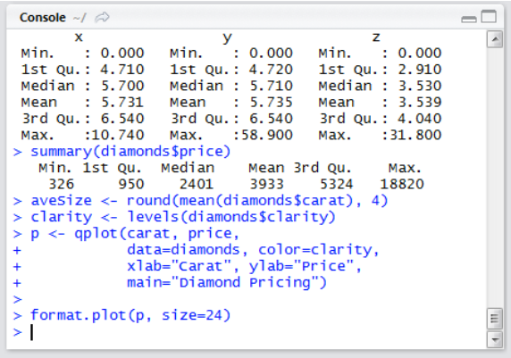

Figure 2.3: RStudio - la console

- Utilisez la **Console** pour inscrire ou coller des commandes et obtenir des résultats…
- … ou pour consulter un fichier d’aide concernant une fonction: inscrivez ’?*Nom_de_la_fonction*. Par exemple: ?mean

Une fenêtre (Figure 2.4) s’ouvre dans votre fureteur, contenant les informations relatives à la fonction pour laquelle une aide est requise.

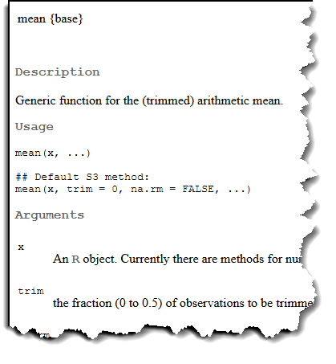

Figure 2.4: Affichage d’aide concernant une fonction

##### 2.3.2.1.2 Le panneau de l’éditeur

Le panneau de l’éditeur (Figure 2.5) est probablement l’espace de travail principal, sous RStudio.

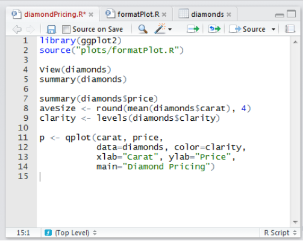

Figure 2.5: RStudio- L’éditeur

- Vous utiliserez la fenêtre **Éditeur** pour créer et éditer des scripts R et des fichiers Rmd (Markdown), principalement.
- La barre de menu dans la portion supérieure de cette fenêtre contient des raccourcis pour transmettre des lignes de code à la console pour une évaluation.

Dans la Figure 2.6, des commandes ont été inscrites dans l’éditeur. Puis, le bouton ‘RUN’ de la barre d’outils a été activé, et l’ensemble des commandes a été transmis et exécuté dans la Console:

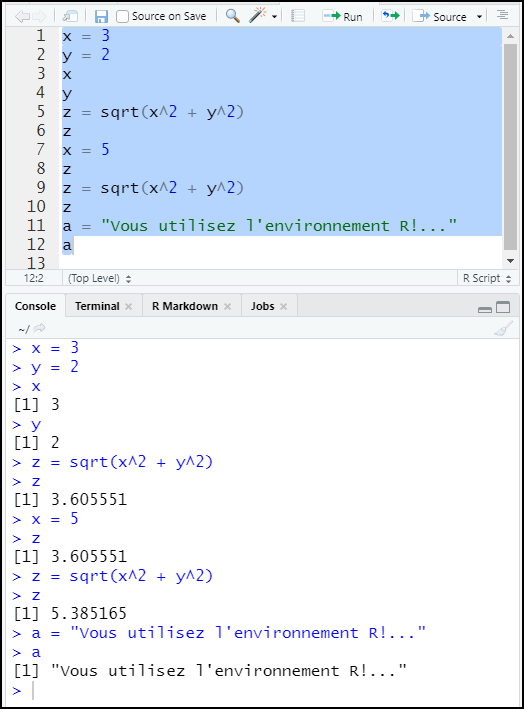

Figure 2.6: RStudio - Exécution de commandes

##### 2.3.2.1.3 La fenêtre *Fichiers/Graphiques/Librairies/Aide*

La fenêtre inférieure-droite (Figure 2.7) est multifonctionnelle, permettant l’affichage graphique, la gestion des librairies et l’examen des documents d’aide.

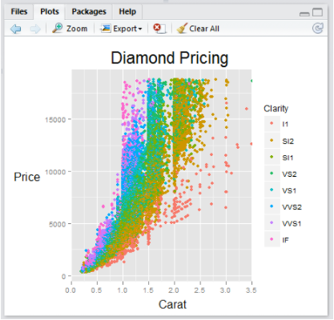

Figure 2.7: RStudio - Affichage graphique

- Par défaut, les graphiques produits dans R sont affichés dans cette fenêtre, sous l’onglet **Plots**
  - La barre de menu vous permet un Zoom, l’exportation de graphiques vers des fichiers et la navigation entre les différents graphiques produits dans une session.
- Lorsqu’une aide est requise (par exemple ‘?mean’), la documentation apparait sous l’onglet **Help**
- Sous l’onglet **Packages**, on peut charger ou retirer une ou plusieurs librairies parmi celles qui sont disponibles dans le système.

##### 2.3.2.1.4 Fenêtre Historique/Environnement/Connexions/Tutoriels

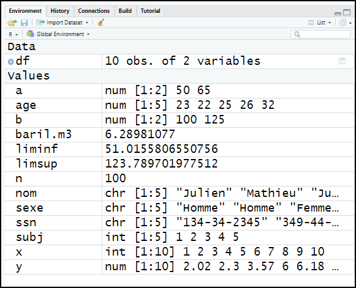

Figure 2.8: RStudio - Environnement/Historique…

- l’affichage des objets se trouvant dans votre espace de travail: variables et fonctions
- l’historique des commandes qui ont été exécutées - les connexions établies avec différentes sources de données
- des tutoriels sur différents aspects de la programmation R

## 2.4 Le langage R: élements de base

R est un langage composé d’une foule d’éléments dont une gamme extrêmement étendue de fonctions. Certaines de ces fonctions font partie du système de base, d’autres proviennent de la communauté R, et d’autres encore que vous pourriez être amenés à écrire! L’ensemble forme un outil très sophistiqué qui ouvre des portes sur une multitude de méthodes de traitement de données. Mais puisqu’il faut un commencement à tout, examinons les éléments les plus simples.

- Sous R, à peu près tout ce que nous faisons, c’est d’appliquer des **fonctions** sur des **données**.
- **Données**: simples ou complexes, comme 7, “sept” , $7.000$, la matrice $\left[ \begin{array}{ccc} 7 & 7 & 7 \\ 7 & 7 & 7\end{array}\right]$
- **Fonctions**: des termes tels que $\log{}$, $+$ (2 arguments), $<$ (2 args), $\mod{}$ (2 args), `mean` (un seul argument). Une fonction peut n’impliquer aucun argument, ou en nécessiter un ou plusieurs.

> Une fonction est un outil qui traite un objet à l’entrée (**arguments**), pour en produire un nouveau à la sortie (**valeur retournée**). Il est possible que cette opération produise aussi des **effets secondaires** (des éléments de sortie secondaires), selon le cas.

### 2.4.1 Les données

Plusieurs types de données existent:

- **Booléennes** (‘boolean’): données binaires. Sous R, ces valeurs sont identifiées par **TRUE** (1) ou **FALSE** (0).
- **Entiers** (‘integers’): nombres entiers (positifs, négatifs ou zéro)
- **Caractères** (‘characters’): séquence plus ou moins longue de caractères **alphanumériques**
- **Nombre réel** (‘Floating point numbers’) : un nombre en continuité avec les valeurs adjacentes, comme 3.14159
- **Données manquantes ou non-définies** (‘Missing or ill-defined values’): `NA`, `NaN`, etc.

### 2.4.2 Opérateurs arithmétiques

Vous pouvez utiliser R, vous vous en doutez bien, comme un super-calculateur!…

| Commande | Description |
| --- | --- |
| **`+, -, *, /`** | addition, soustraction, multiplication, division |
| **`^`** | élever à la puissance… |
| **`%%`** | Ce qui reste après une division (ex: `8 %% 3 = 2`) |
| **`( )`** | changement dans l’ordre d’exécution des opérations |
| **`log(), exp()`** | logarithmes et exponentiation (ex: `log(10) = 2.302`) |
| **`sqrt()`** | racine carrée |
| **`round()`** | arrondi à l’entier le plus près (ex: `round(2.3) = 2`) |
| **`floor(), ceiling()`** | arrondi vers le bas, ou le haut |
| **`abs()`** | valeur absolue |

```r
7 + 5 # Addition
```

```
#> [1] 12
```

```r
7 - 5 # Soustraction
```

```
#> [1] 2
```

```r
7 * 5 # Multiplication
```

```
#> [1] 35
```

```r
7 ^ 5 # Exponentiation
```

```
#> [1] 16807
```

```r
7 / 5   # Division
```

```
#> [1] 1.4
```

```r
7 %% 5  # Modulus
```

```
#> [1] 2
```

```r
7 %/% 5 # Division entière
```

```
#> [1] 1
```

Il existe aussi des termes faisant référence à des constantes dont un exemple est **pi**:

```r
2*pi*5        # Circonférence d'un cercle de rayon = 5
```

```
#> [1] 31.41593
```

```r
(4*pi*5^2)/3  # Volume d'une sphère de rayon = 5
```

```
#> [1] 104.7198
```

Plusieurs autres types d’opérations impliquent des fonctions, comme on le verra plus loin. Une d’entre elles est **sqrt()**, qui permet d’obtenir la racine carrée de son argument (le contenu des parenthèses). Par exemple, la racine carrée de 98.74 est:

```r
a <- 98.74
sqrt(a)
```

```
#> [1] 9.9368
```

De la même manière, notons les fonctions:

```r
round(3.14159,2)  # Arrondissement
```

```
#> [1] 3.14
```

```r
floor(3.14159)    # Arrondissement à l'entier inférieur
```

```
#> [1] 3
```

```r
ceiling(3.14159)  # Arrondissement à l'entier supérieur
```

```
#> [1] 4
```

Plusieurs autres fonctions de ce type s’ajouteront bientôt à la liste!… et il est très probable que vous soyez amenés à écrire vos propres fonctions sous peu!

### 2.4.3 Exercice 2

Utilisez l’éditeur de RStudio pour répondre aux questions suivantes:

1. La largeur d’un rectangle mesure 4 centimètres, et sa hauteur mesure 18 centimètres. Quelle est la périphérie de ce rectangle?
2. Quelle est la surface du rectangle décrit en (1)?
3. Dans un mètre, il y a 39.37008 pouces. Combien y’a-t’il de pouces dans 2.5 mètres?
4. Le volume d’une sphère est égal à $(4\pi r^2)/3$. Quel serait le volume d’une sphère dont le **diamètre** serait égal à 8.92745?
5. Si x = 4.5327 et y = 8.4893, quelle est la valeur de l’expression:
   $$\sqrt{(x^3+y^4)}-(x/2+x\cdot y/5)^3$$

### 2.4.4 Opérateurs de comparaisons logiques

Les **Comparaisons** sont des opérateurs binaires. Elles prennent deux objets, les comparent, et produisent une valeur booléenne (‘TRUE’ ou ‘FALSE’):

```r
7 > 5   # plus grand que...
```

```
#> [1] TRUE
```

```r
7 < 5   # plus petit que...
```

```
#> [1] FALSE
```

```r
7 >= 7  # plus grand ou égal...
```

```
#> [1] TRUE
```

```r
7 <= 5  # plus petit ou égal...
```

```
#> [1] FALSE
```

```r
7 == 5  # égal à...
```

```
#> [1] FALSE
```

```r
7 != 5  # différent de...
```

```
#> [1] TRUE
```

```r
"Carl"=="Marie"   # comparaison de caractères alphanumériques
```

```
#> [1] FALSE
```

```r
"Carl"<"Marie"    # Ordre alphabétique
```

```
#> [1] TRUE
```

```r
# Comparaison de portions de texte (2 premiers caractères)
substr("Marie",1,2)==substr("Judith",1,2)
```

```
#> [1] FALSE
```

À ces opérateurs logiques, on peut ajouter:

**!x** : Négation de x

```r
!(5>7)
```

```
#> [1] TRUE
```

**%in%**: Est-ce que le premier argument se trouve dans le second?

```r
x <- c(1,2,3,4)
y <- c(2,4,6,8,10)
x %in% y
```

```
#> [1] FALSE  TRUE FALSE  TRUE
```

**identical()**: Est-ce que les arguments sont identiques?

```r
identical(x,y)
```

```
#> [1] FALSE
```

```r
a <- "Jacques"
b <- "Jacques"
identical(a,b)
```

```
#> [1] TRUE
```

Plusieurs autres fonctions s’ajouteront à cette courte liste selon les besoins.

### 2.4.5 Opérateurs Booléens

**&** (‘and’): l’opérateur ‘&’ prend deux arguments logiques et retourne TRUE seulement s’ils sont tous les deux vrais:

```r
x <- c(TRUE,TRUE,FALSE,FALSE)
y <- c(TRUE,FALSE,TRUE,FALSE)
x & y
```

```
#> [1]  TRUE FALSE FALSE FALSE
```

**|** (‘or’): L’opérateur ‘|’ prend aussi deux arguments logiques et retourne TRUE si **au moins** un d’eux est vrai:

```r
x <- c(TRUE,TRUE,FALSE,FALSE)
y <- c(TRUE,FALSE,TRUE,FALSE)
x | y
```

```
#> [1]  TRUE  TRUE  TRUE FALSE
```

**xor()** : OR exclusif: la condition est vraie seulement si un seul des éléments comparés est vrai:

```r
x <- c(TRUE,TRUE,FALSE,FALSE)
y <- c(TRUE,FALSE,TRUE,FALSE)
xor(x,y)
```

```
#> [1] FALSE  TRUE  TRUE FALSE
```

Ces opérateur seront particulièrement utiles lorsqu’une programmation nécessite des branchements conditionnels. Dans ces cas, les opérateurs logiques et booléens seront généralement liés:

```r
(5 > 7)               # Condition A
```

```
#> [1] FALSE
```

```r
(6*7 == 42)           # Condition B
```

```
#> [1] TRUE
```

```r
(5 > 7) & (6*7 == 42) # Condition A ET Condition B
```

```
#> [1] FALSE
```

```r
(5 > 7) | (6*7 == 42) # Condition A OU Condition B
```

```
#> [1] TRUE
```

```r
xor((5 > 7), (6*7 == 42))
```

```
#> [1] TRUE
```

### 2.4.6 Autres fonctions utiles

- **typeof()** : Fonction affichant le type d’objet (type = **integer**, **double**, **logical**, **complex**, **character**). Par exemple:

```r
x <- "Pierre"
typeof(x)
```

```
#> [1] "character"
```

```r
x <- 3.14159
typeof(x)
```

```
#> [1] "double"
```

```r
x <- 1:5
typeof(x)
```

```
#> [1] "integer"
```

```r
typeof(x>2)
```

```
#> [1] "logical"
```

- **is._type_()** Fonction retournant des valeurs booléennes si l’argument est d’un type donné (type = **integer**, **double**, **logical**, **complex**, **character**). Par exemple:

```r
x <- "Pierre"
is.character(x)
```

```
#> [1] TRUE
```

```r
x <- 3.14159
is.integer(x)
```

```
#> [1] FALSE
```

```r
x <- 1:5
is.logical(x)
```

```
#> [1] FALSE
```

```r
is.logical(x>2)
```

```
#> [1] TRUE
```

- **as._type_()** : Fonction qui tente de “convertir” son argument en une valeur d’un autre type (eg: alphanumérique vers numérique). Par exemple:

```r
x <- "Pierre"
as.logical(x)   # La conversion n'est pas possible
```

```
#> [1] NA
```

```r
x <- "3.14159"
typeof(x)
```

```
#> [1] "character"
```

```r
as.numeric(x)   # Conversion d'un texte en valeur numérique
```

```
#> [1] 3.14159
```

```r
x <- 3.14156
typeof(x)
```

```
#> [1] "double"
```

```r
as.character(x) # Conversion d'une valeur numérique en texte
```

```
#> [1] "3.14156"
```

**Cas Spécial**: **as.factor()** est une fonction importante permettant d’informer R lorsque des nombres sont des encodages et non pas des valeurs numériques (e.g., 1 = primaire; 2 = secondaire; 3 = Baccalauréat)

### 2.4.7 Variables

Comme c’est le cas en algèbre, les variables sont une forme de raccourci. Au lieu d’écrire 3.1415926… tout le temps, nous pouvons simplement écrire **pi**.

Les variables sont créées avec l’**opérateur d’assignation**, `<-`, `->`, ou `=`. L’affectation de données à une variable se fait généralemen de droite à gauche: la valeur de droite est affectée au nom de gauche. Mais l’inverse fonctionne aussi (assignation ‘fléchée’ seulement). Donc, 3 façons de d’assigner une valeur à une variable:

```r
x = 8   # Non recommandé: confusion possible avec '=='
x <- 8  # Méthode préférée!
8 -> x
x
```

```
#> [1] 8
```

Vous pouvez utiliser presque n’importe quoi comme nom de variable dans R, à la condition de respecter les quelques règles suivantes:

1. le nom d’une variable est formé de lettres et de chiffres, majuscules et/ou minuscules, et des deux seuls symboles permis: ‘.’ et ‘_’ .
2. Le nom d’une variable ne doit pas commencer par un nombre ou un ‘_’, mais peut commencer par un ‘.’ (exemple: .x <- 5)
3. Le nom d’une variable est sensible à la case: A1 et a1 sont deux variables différentes!

Des exemples valides de noms de variables seraient:

```r
abcd <- 3
Abcd <- 5
A.bcd <- 8
.a.Bcd <- 12
A_bcd <- 2
A1.B2_c3 <- 7
```

**Notes:**

1. Le choix des noms de variables a un impact sur la lecture du code R. Des noms descriptifs de la nature des variables rend plus facile cette lecture.
2. Variables définies dans l’espace de travail:
- On peut déterminer les variables présentes dans l’environnement en utilisant la fonction **ls()**:

```r
ls()
```

```
#> [1] "A.bcd"    "A_bcd"    "A1.B2_c3" "abcd"     "Abcd"     "x"
```

On peut éliminer une ou plusieurs variables avec la fonction **rm()**:

```r
rm("A.bcd")
ls()
```

```
#> [1] "A_bcd"    "A1.B2_c3" "abcd"     "Abcd"     "x"
```

3. L’assignation de valeurs à une variable existante écrase la valeur existante